# finalProject_Analysis

R Markdown

# 1.Large fire predictor

Through EDA, we found that the fire size class in California has a very high frequency in A and B fire class size. Those sizes of wildfires may not be a threats to environment and properties since they could disappear soon. The size of C class and above could be dangerous as the burned size grows fast.

## Preparing the data

```
## 'data.frame':    23376 obs. of  5 variables:
##  $ time               : chr  "1950-01-01 00:00:00+00:00" "1950-01-02 00:00:00+00:00" "1950-01-03 00:00:00+00:00" "1950-01-04 00:00:00+00:00" ...
##  $ tair_day_livneh_vic: num  4.14 1.77 -3.09 -3.59 -2.75 ...
##  $ month              : chr  "01" "01" "01" "01" ...
##  $ year               : chr  "1950" "1950" "1950" "1950" ...
##  $ DOY                : chr  "001" "002" "003" "004" ...
```

```
## 'data.frame':    23376 obs. of  6 variables:
##  $ year                     : int  1950 1950 1950 1950 1950 1950 1950 1950 1950 1950 ...
##  $ DOY                      : int  1 2 3 4 5 6 7 8 9 10 ...
##  $ tair_day_livneh_vic      : num  4.14 1.77 -3.09 -3.59 -2.75 ...
##  $ month                    : chr  "01" "01" "01" "01" ...
##  $ soilmoist1_day_livneh_vic: num  18.3 18.5 18.3 18.3 18.1 ...
##  $ rainfall_day_livneh_vic  : num  0.67193 0.79325 0.07883 0.08991 0.00174 ...
```

```
## 'data.frame':    8036 obs. of  8 variables:
##  $ year                     : int  1992 1992 1992 1992 1992 1992 1992 1992 1992 1992 ...
##  $ DOY                      : int  1 2 3 4 5 6 7 8 9 10 ...
##  $ tair_day_livneh_vic      : num  3.78 4.17 4.19 4.87 4.94 ...
##  $ month                    : chr  "01" "01" "01" "01" ...
##  $ soilmoist1_day_livneh_vic: num  20.2 20.5 21.4 23.6 25.1 ...
##  $ rainfall_day_livneh_vic  : num  0.0616 1.1337 3.0754 7.0797 10.8035 ...
##  $ n                        : num  0 0 0 0 0 0 0 0 0 0 ...
##  $ fire                     : num  0 0 0 0 0 0 0 0 0 0 ...
```

```
## 'data.frame':    8036 obs. of  8 variables:
##  $ year                     : num  1992 1992 1992 1992 1992 ...
##  $ DOY                      : num  2 3 4 5 6 7 8 9 10 11 ...
##  $ tair_day_livneh_vic      : num  3.78 4.17 4.19 4.87 4.94 ...
##  $ month                    : chr  "01" "01" "01" "01" ...
##  $ soilmoist1_day_livneh_vic: num  20.2 20.5 21.4 23.6 25.1 ...
##  $ rainfall_day_livneh_vic  : num  0.0616 1.1337 3.0754 7.0797 10.8035 ...
##  $ n                        : num  0 0 0 0 0 0 0 0 0 0 ...
##  $ fire                     : num  0 0 0 0 0 0 0 0 0 0 ...
```

## Large fire prediction model, by logit regression

Logit Regression : fire ~ tair_day_livneh_vic + soilmoist1_day_livneh_vic

|  | Estimate | Std. Error | z value | Pr(>\|z\|) |
| --- | --- | --- | --- | --- |
| (Intercept) | 3.0691 | 0.3117 | 9.8458 | 0 |
| tair_day_livneh_vic | 0.1461 | 0.0080 | 18.1739 | 0 |
| soilmoist1_day_livneh_vic | -0.3157 | 0.0145 | -21.7253 | 0 |

```
## Area under the curve: 0.9017
```

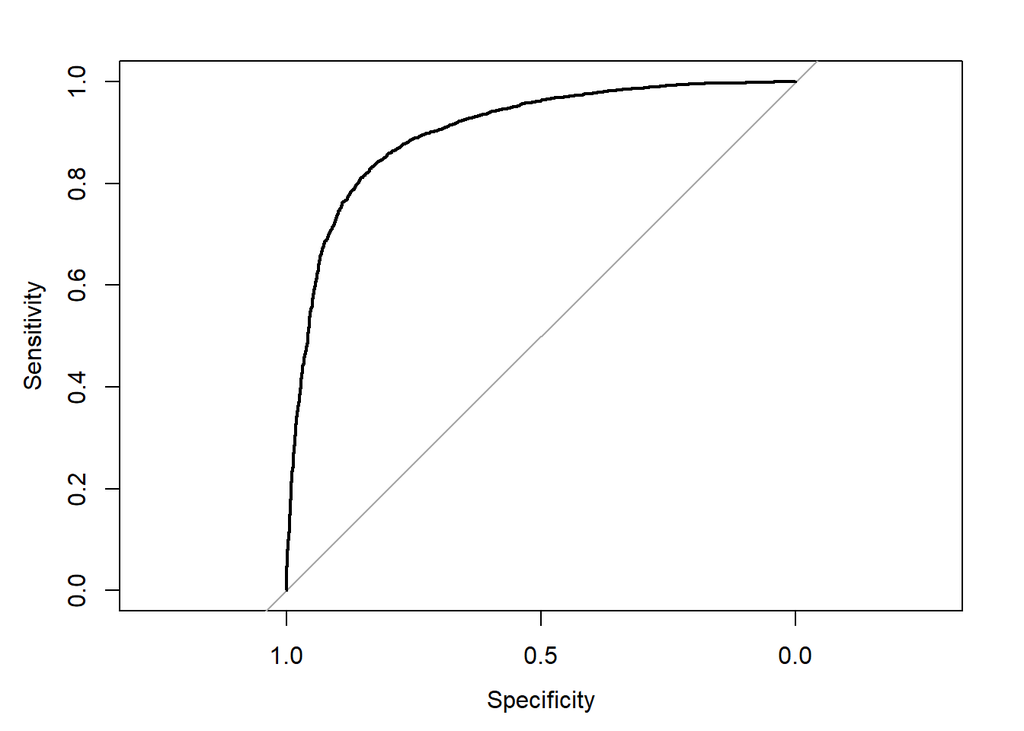

Confusion matrix for large fire predictor

|  | Predicted 0 | Predicted 1 | Total |
| --- | --- | --- | --- |
| Actual 0 | 3265 | 659 | 3924 |
| Actual 1 | 692 | 3420 | 4112 |
| Total | 3957 | 4079 | 8036 |

To try to increase usability for the model, we try to make a model to predict the probability in next day:

Predicting Probability : fire ~ tair_day_livneh_vic + soilmoist1_day_livneh_vic + soilmoist1_day_livneh_vic +

Predicting Probability : rainfall_day_livneh_vic

|  | Estimate | Std. Error | z value | Pr(>\|z\|) |
| --- | --- | --- | --- | --- |
| (Intercept) | 2.4707 | 0.3245 | 7.6148 | 0 |
| tair_day_livneh_vic | 0.1508 | 0.0081 | 18.6813 | 0 |
| soilmoist1_day_livneh_vic | -0.2743 | 0.0158 | -17.3927 | 0 |
| rainfall_day_livneh_vic | -0.1312 | 0.0256 | -5.1318 | 0 |

```
## Area under the curve: 0.9002
```

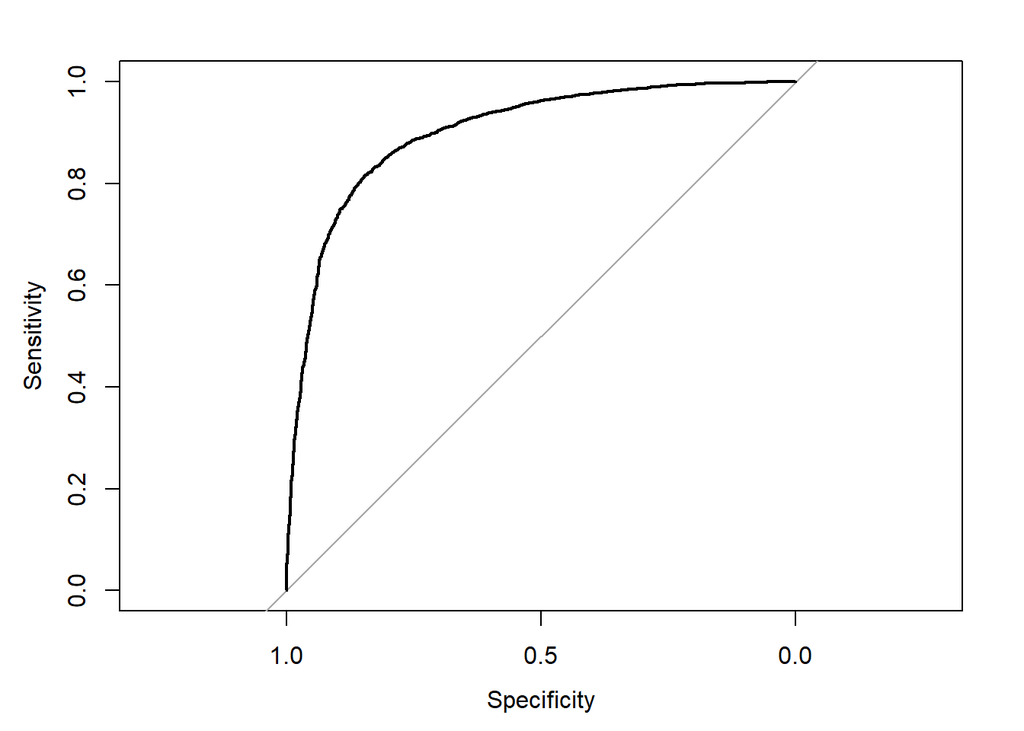

Confusion matrix for large fire predictor

|  | Predicted 0 | Predicted 1 | Total |
| --- | --- | --- | --- |
| Actual 0 | 3244 | 680 | 3924 |
| Actual 1 | 689 | 3423 | 4112 |
| Total | 3933 | 4103 | 8036 |

Logit Regression : fire ~ tair_day_livneh_vic

|  | Estimate | Std. Error | z value | Pr(>\|z\|) |
| --- | --- | --- | --- | --- |
| (Intercept) | -3.7380 | 0.0821 | -45.5091 | 0 |
| tair_day_livneh_vic | 0.2833 | 0.0058 | 48.6031 | 0 |

```
## Area under the curve: 0.8799
```

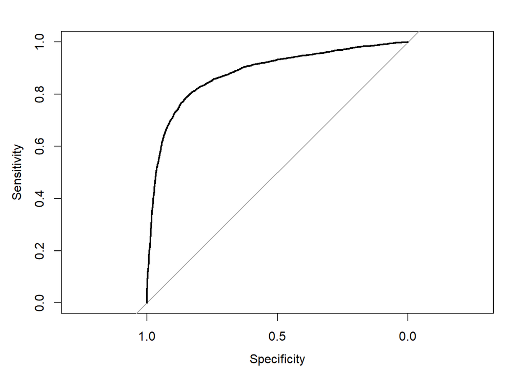

Confusion matrix for large fire predictor

|  | Predicted 0 | Predicted 1 | Total |
| --- | --- | --- | --- |
| Actual 0 | 3222 | 702 | 3924 |
| Actual 1 | 780 | 3332 | 4112 |
| Total | 4002 | 4034 | 8036 |

The results suppose that with temperature rainfall and soil moisture data from today; We have AUC 0.9 for predicting the the large fire in next day If we try to make a convenient model that require only temperature to predict the probability, the AUC is 0.88.

## 1.2 Multinomial Regression Models

we are try to figure out that can we predict the specific fire size of a large wildfire(class c or above)

```
## Call:
## multinom(formula = FIRE_SIZE_CLASS ~ tair_day_livneh_vic + soilmoist1_day_livneh_vic +
##     rainfall_day_livneh_vic, data = train)
##
## Coefficients:
##   (Intercept) tair_day_livneh_vic soilmoist1_day_livneh_vic
## D   -2.030170          0.01501637                0.01475982
## E   -2.361445          0.02827772               -0.02724998
## F   -4.801239          0.07723304                0.05224938
## G   -4.123844          0.06681124               -0.03707137
##   rainfall_day_livneh_vic
## D             0.024976191
## E             0.055307070
## F            -0.008234025
## G            -0.300388755
##
## Std. Errors:
##   (Intercept) tair_day_livneh_vic soilmoist1_day_livneh_vic
## D   0.4369902         0.009060464                0.02354973
## E   0.5811933         0.011994366                0.03187729
## F   0.7548843         0.015876431                0.04053880
## G   1.0896840         0.022497417                0.06116466
##   rainfall_day_livneh_vic
## D              0.04090148
## E              0.05361488
## F              0.07622425
## G              0.17500733
##
## Residual Deviance: 18899.78
## AIC: 18931.78
```

```
## [1] 0
```

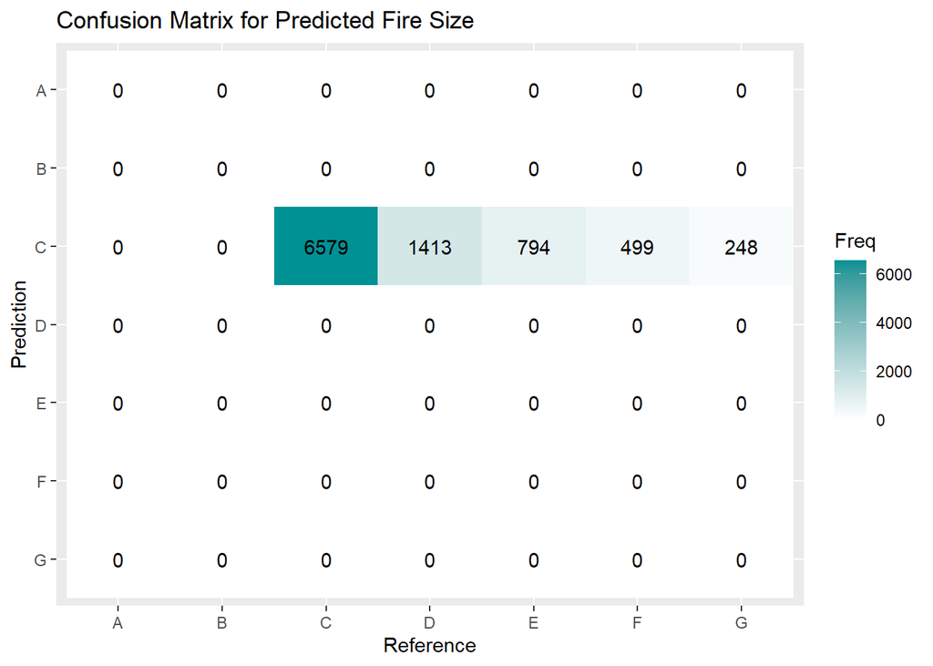

```
## [1] 0
```

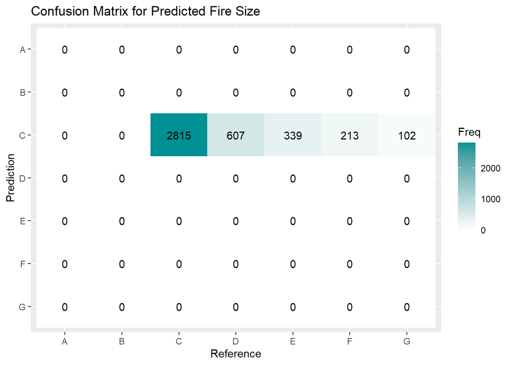

We found that since the large wildfire dataset is not balanced, the model fails to predict class since the model strongly predict results as C class, this suppose that we need more data and try alternative model on predict such categroy.

# 2. regression for long term

We also wanted to evaluate the long term effect on the wildfires by nature factors. We tried to predict the cases of wildfires, average fire size and total burned fire by nature factors.

## 2.1 regression for case,firesize, total burning area

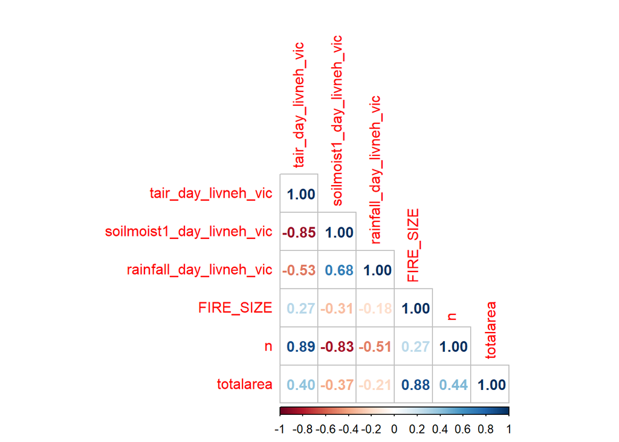

From the corrplot, we can find that the number of case have strong correlation with environment variable. And the fire size, total area burned have some correlation with environment variable. We try to use linear model for those predicted variable, the result suppose that the model is not fit well. Then, we take log to those predicted variable. Then the models are improved.

Linear Regression : log(n) ~ tair_day_livneh_vic + +soilmoist1_day_livneh_vic

|  | Estimate | Std. Error | t value | Pr(>\|t\|) |
| --- | --- | --- | --- | --- |
| (Intercept) | 8.8261 | 0.2806 | 31.4571 | 0 |
| tair_day_livneh_vic | 0.0526 | 0.0068 | 7.7415 | 0 |
| soilmoist1_day_livneh_vic | -0.2322 | 0.0126 | -18.4468 | 0 |

```
##       tair_day_livneh_vic soilmoist1_day_livneh_vic
##                  3.653691                  3.653691
```

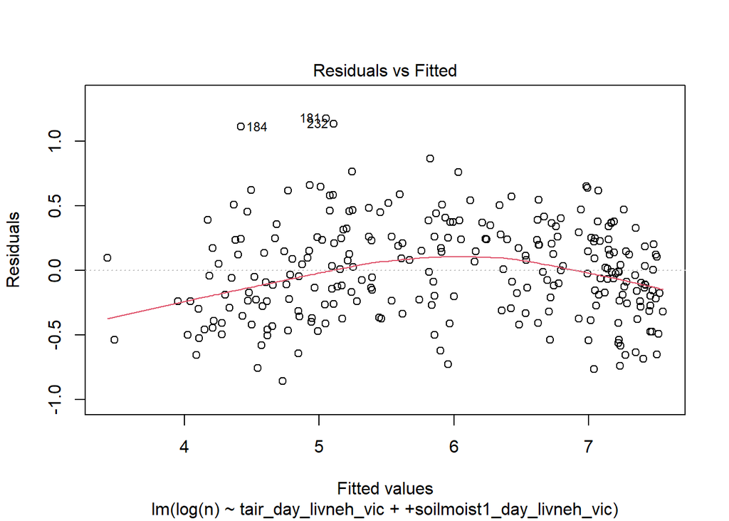

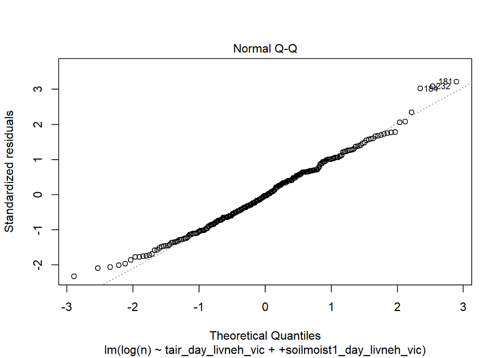

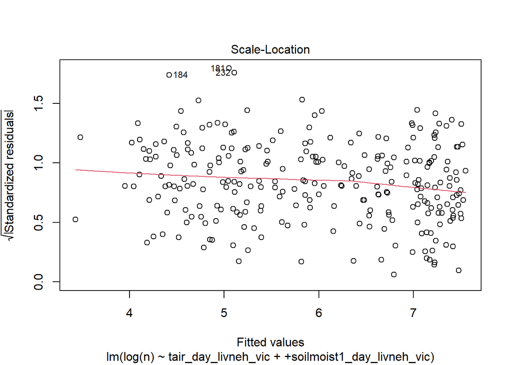

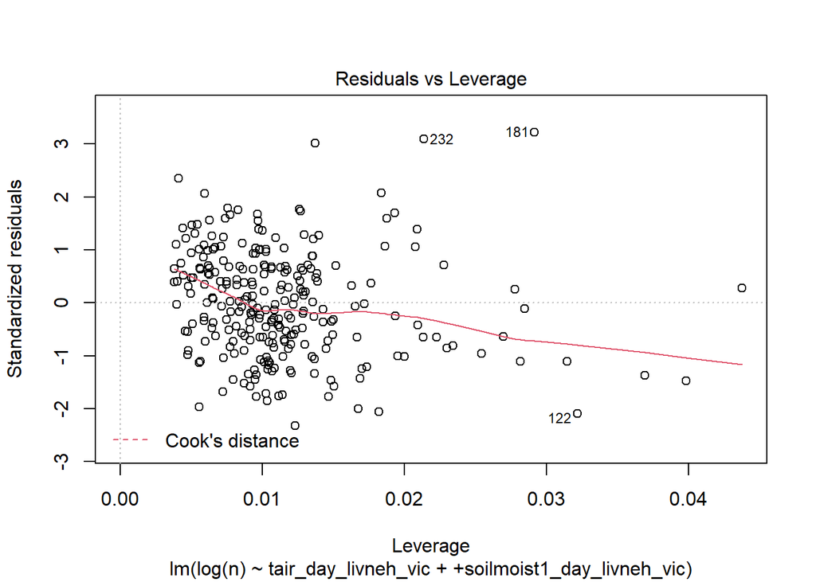

Linear Regression : log(FIRE_SIZE) ~ tair_day_livneh_vic + +soilmoist1_day_livneh_vic

|  | Estimate | Std. Error | t value | Pr(>\|t\|) |
| --- | --- | --- | --- | --- |
| (Intercept) | 6.4512 | 0.8955 | 7.2041 | 0.0000 |
| tair_day_livneh_vic | 0.0409 | 0.0217 | 1.8858 | 0.0604 |
| soilmoist1_day_livneh_vic | -0.2994 | 0.0402 | -7.4540 | 0.0000 |

```
##       tair_day_livneh_vic soilmoist1_day_livneh_vic
##                  3.653691                  3.653691
```

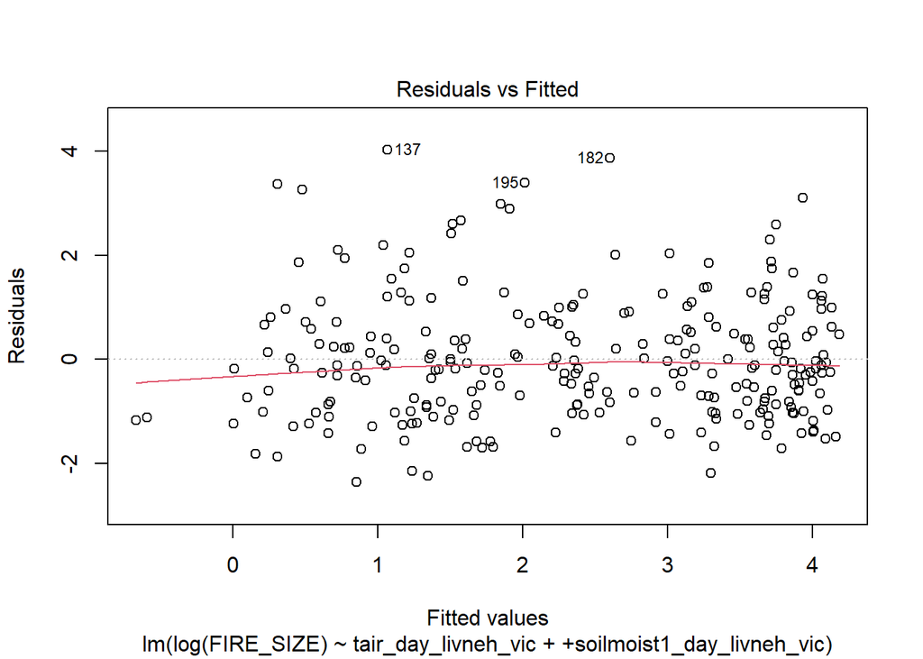

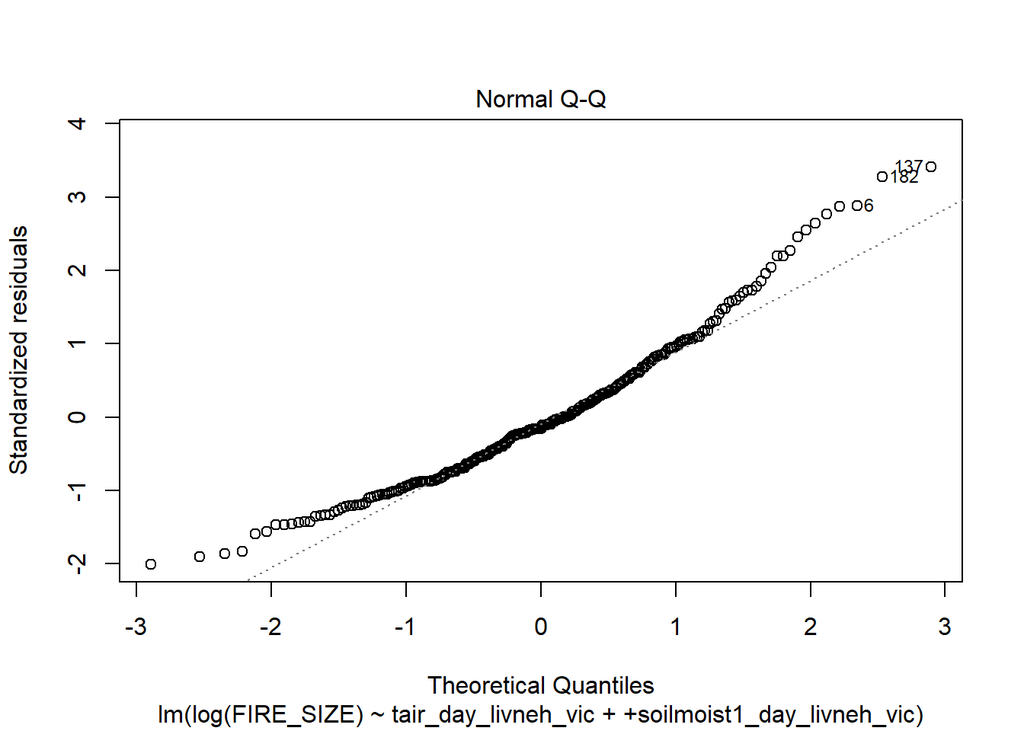

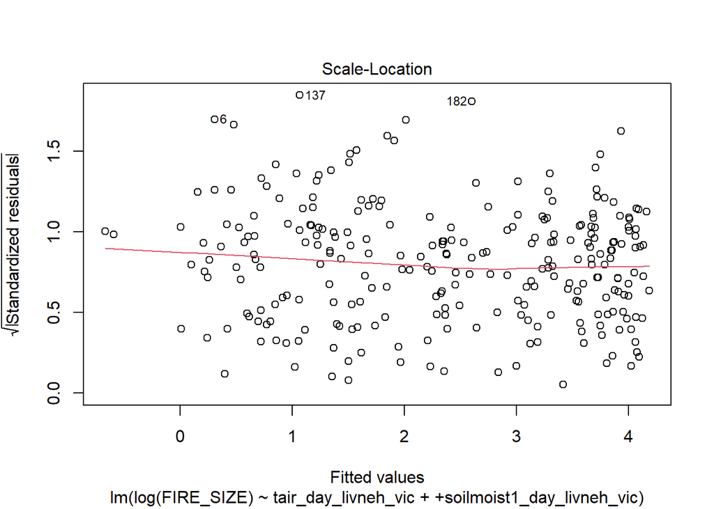

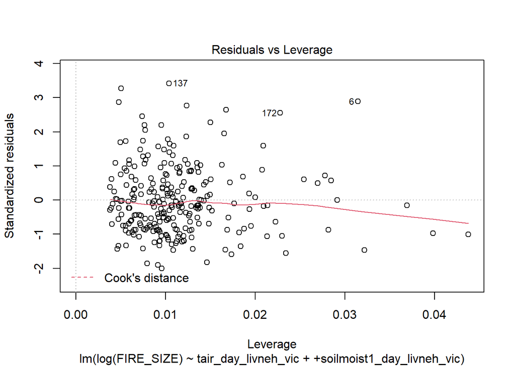

Linear Regression : log(totalarea) ~ tair_day_livneh_vic + +soilmoist1_day_livneh_vic

|  | Estimate | Std. Error | t value | Pr(>\|t\|) |
| --- | --- | --- | --- | --- |
| (Intercept) | 15.2773 | 0.9527 | 16.0351 | 0e+00 |
| tair_day_livneh_vic | 0.0936 | 0.0231 | 4.0523 | 1e-04 |
| soilmoist1_day_livneh_vic | -0.5316 | 0.0427 | -12.4385 | 0e+00 |

```
##       tair_day_livneh_vic soilmoist1_day_livneh_vic
##                  3.653691                  3.653691
```

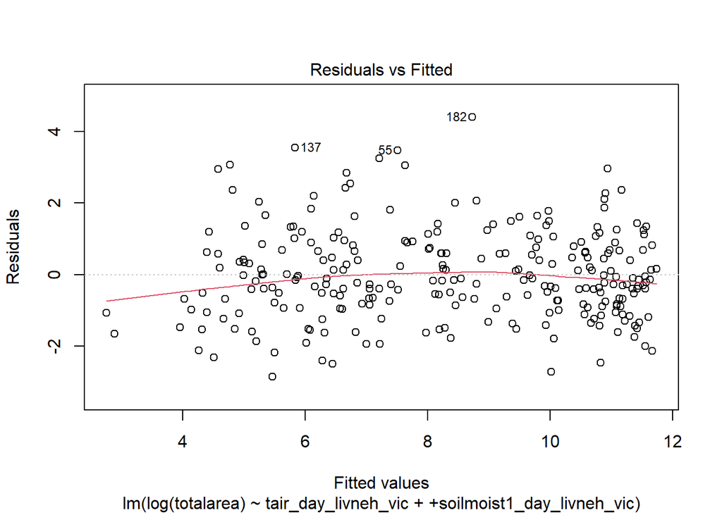

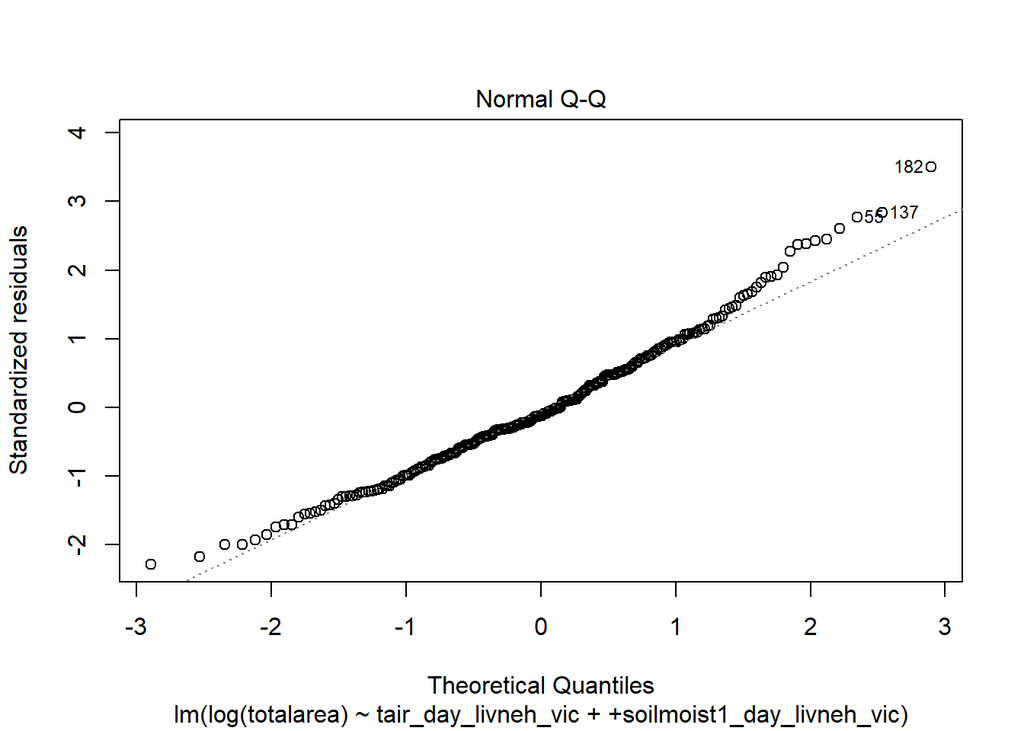

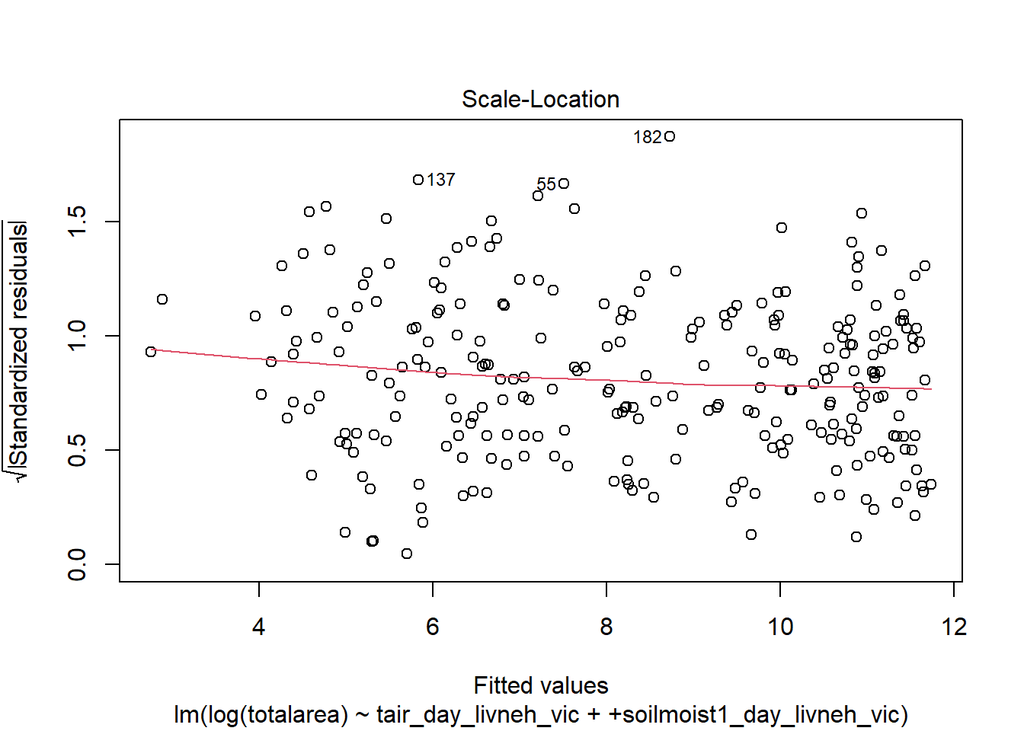

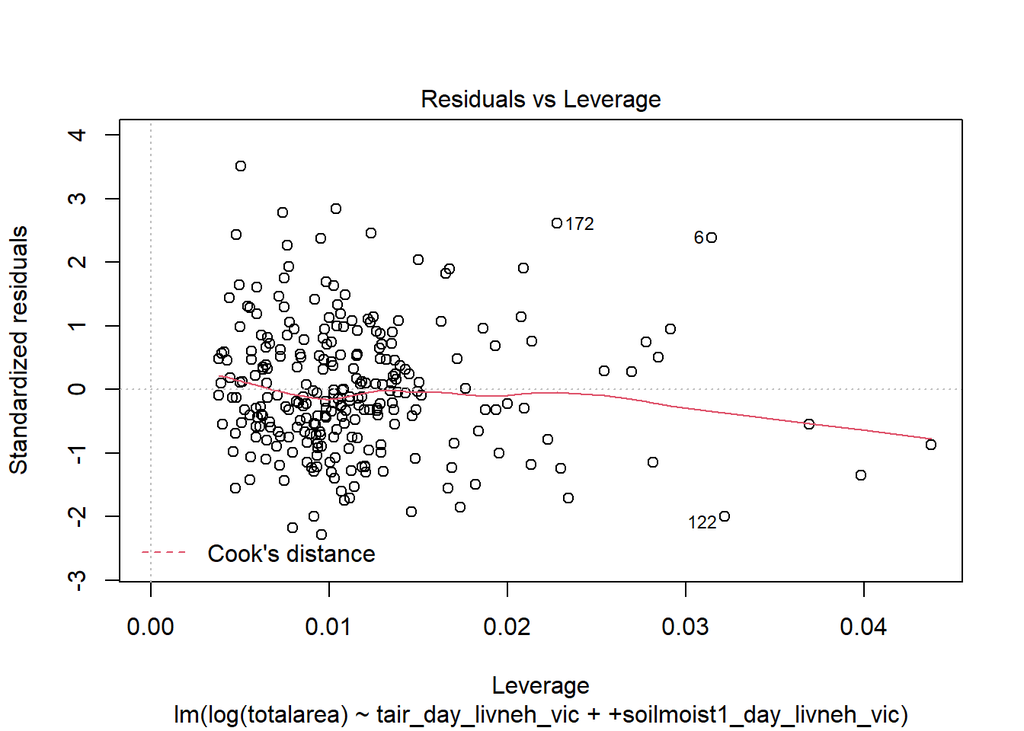

## 2.2 Large wildfire(c class or above) model

We build models to predict the large wildfire number firesize and total burned area.

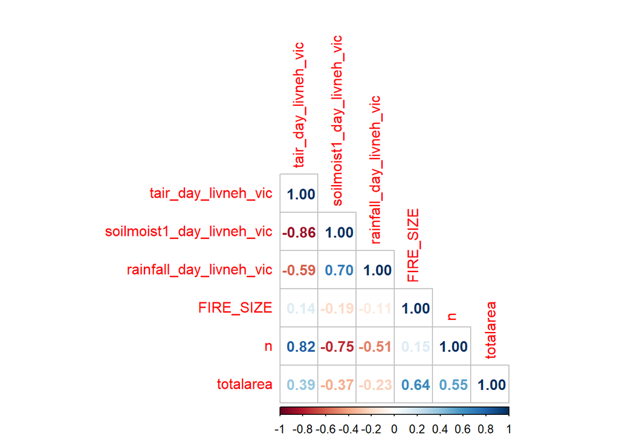

Case Model: log(n) ~ tair_day_livneh_vic + +soilmoist1_day_livneh_vic

|  | Estimate | Std. Error | t value | Pr(>\|t\|) |
| --- | --- | --- | --- | --- |
| (Intercept) | 6.1644 | 0.4773 | 12.9163 | 0 |
| tair_day_livneh_vic | 0.0904 | 0.0112 | 8.0897 | 0 |
| soilmoist1_day_livneh_vic | -0.2847 | 0.0219 | -12.9789 | 0 |

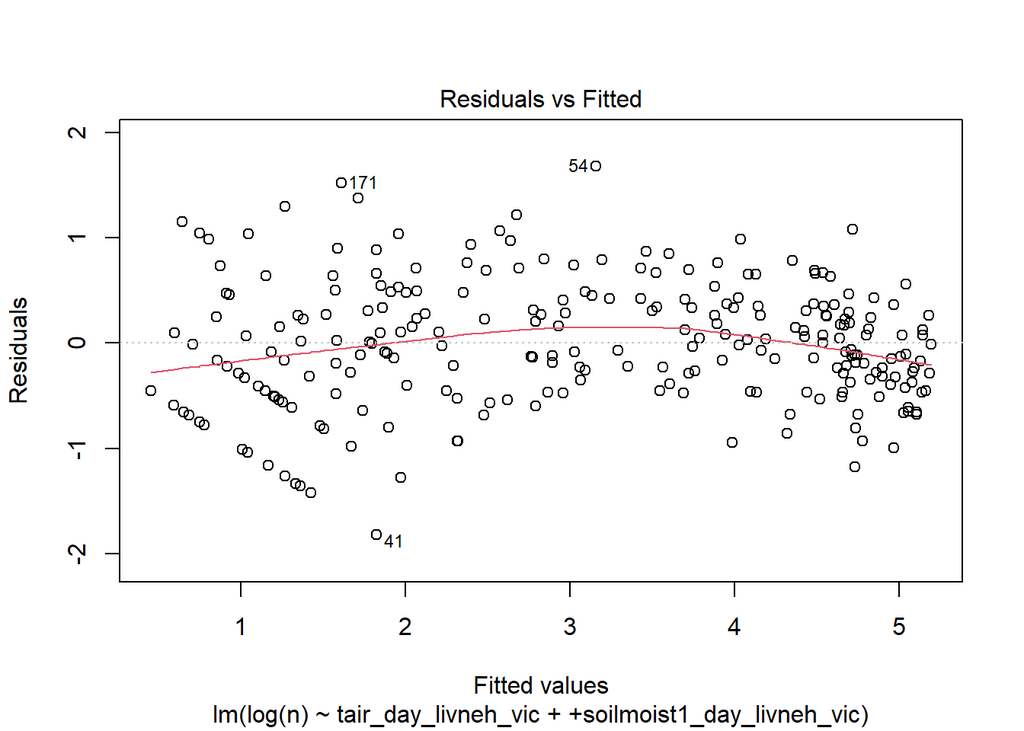

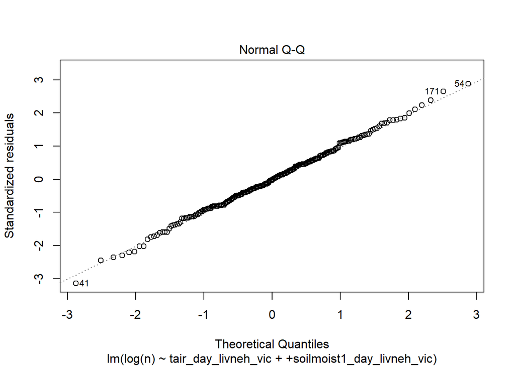

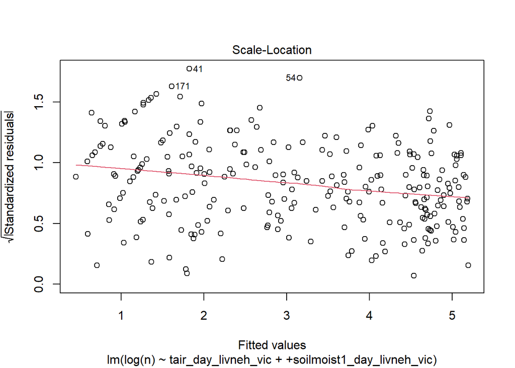

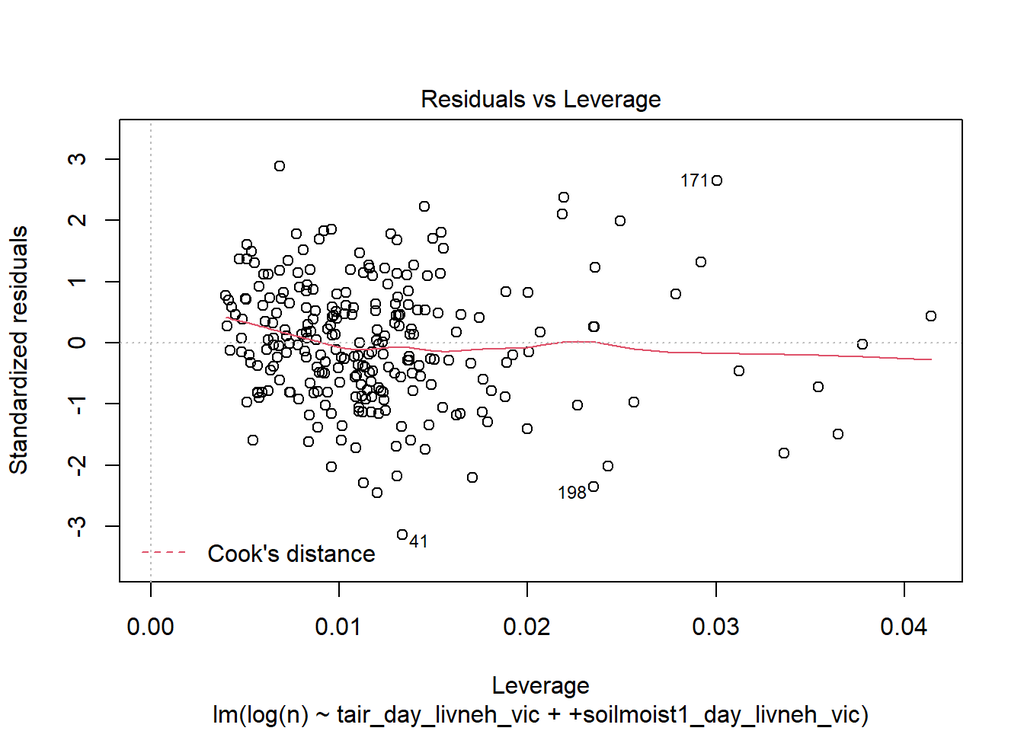

```
##       tair_day_livneh_vic soilmoist1_day_livneh_vic
##                  3.733188                  3.733188
```

Avg. Size Model Model: log(FIRE_SIZE) ~ tair_day_livneh_vic + +soilmoist1_day_livneh_vic

|  | Estimate | Std. Error | t value | Pr(>\|t\|) |
| --- | --- | --- | --- | --- |
| (Intercept) | 7.4492 | 0.9322 | 7.9908 | 0.0000 |
| tair_day_livneh_vic | 0.0407 | 0.0218 | 1.8642 | 0.0635 |
| soilmoist1_day_livneh_vic | -0.1770 | 0.0428 | -4.1300 | 0.0000 |

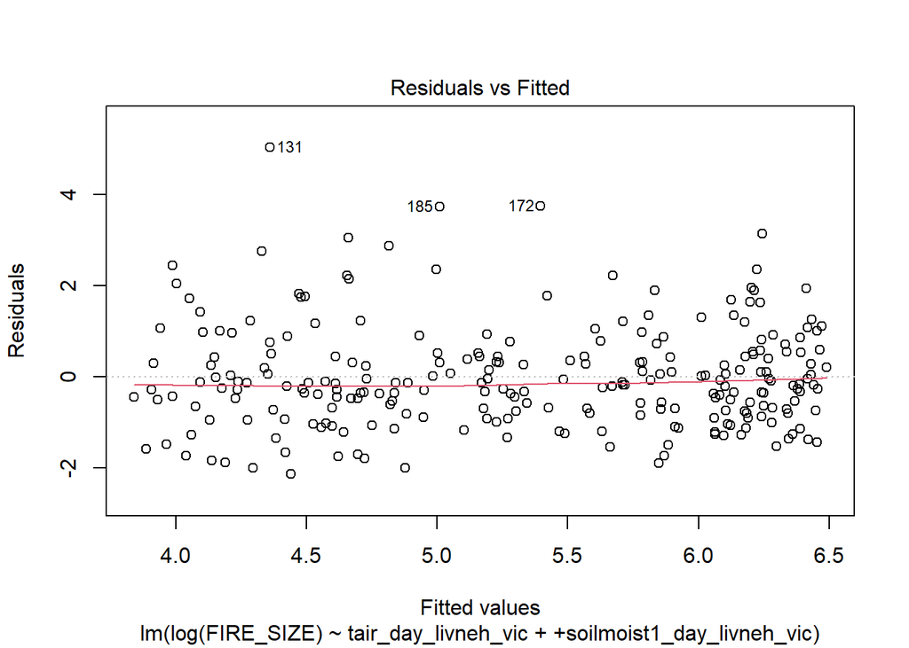

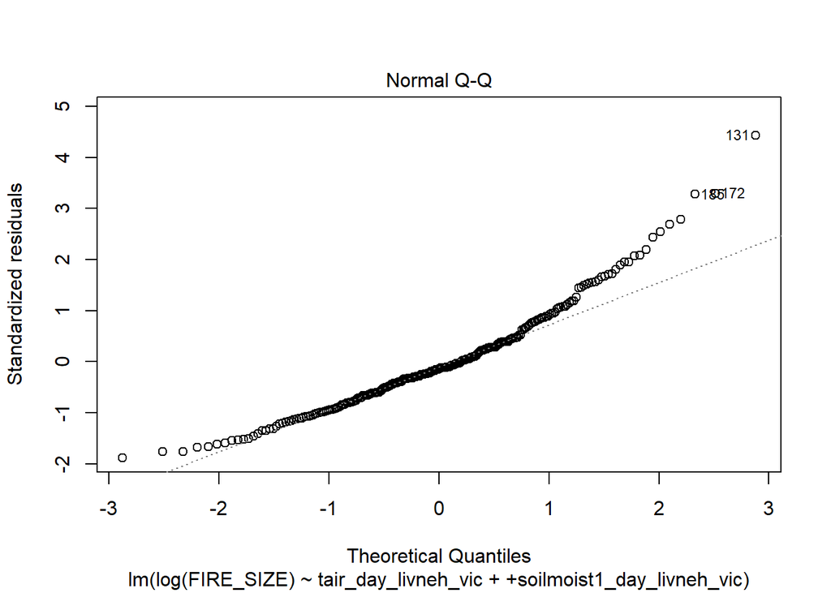

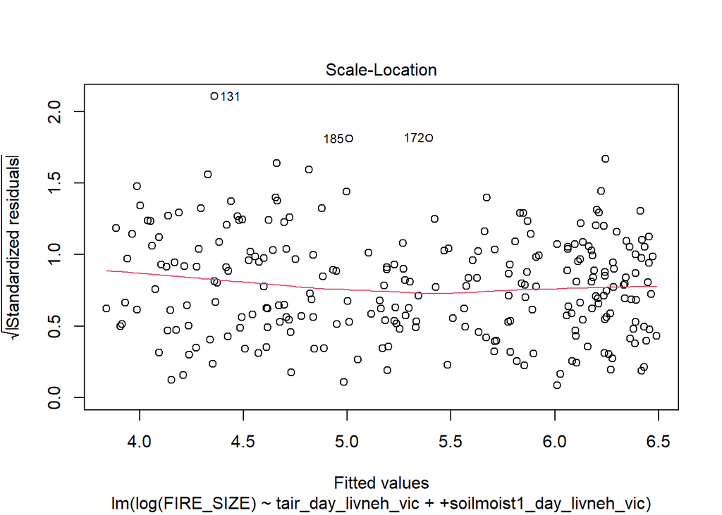

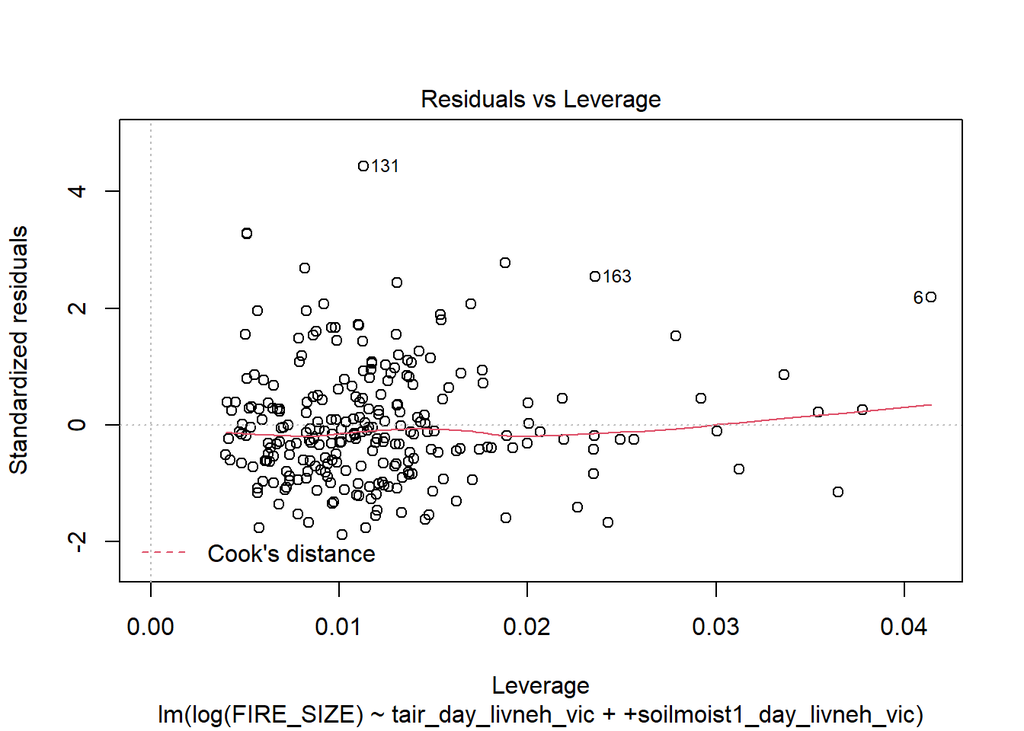

```
##       tair_day_livneh_vic soilmoist1_day_livneh_vic
##                  3.733188                  3.733188
```

Burn Area Model: log(totalarea) ~ tair_day_livneh_vic + +soilmoist1_day_livneh_vic

|  | Estimate | Std. Error | t value | Pr(>\|t\|) |
| --- | --- | --- | --- | --- |
| (Intercept) | 13.6135 | 1.1019 | 12.3546 | 0 |
| tair_day_livneh_vic | 0.1310 | 0.0258 | 5.0809 | 0 |
| soilmoist1_day_livneh_vic | -0.4616 | 0.0506 | -9.1154 | 0 |

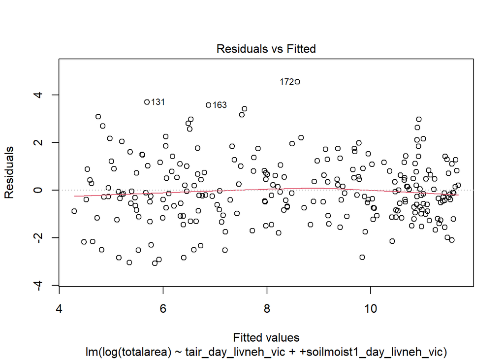

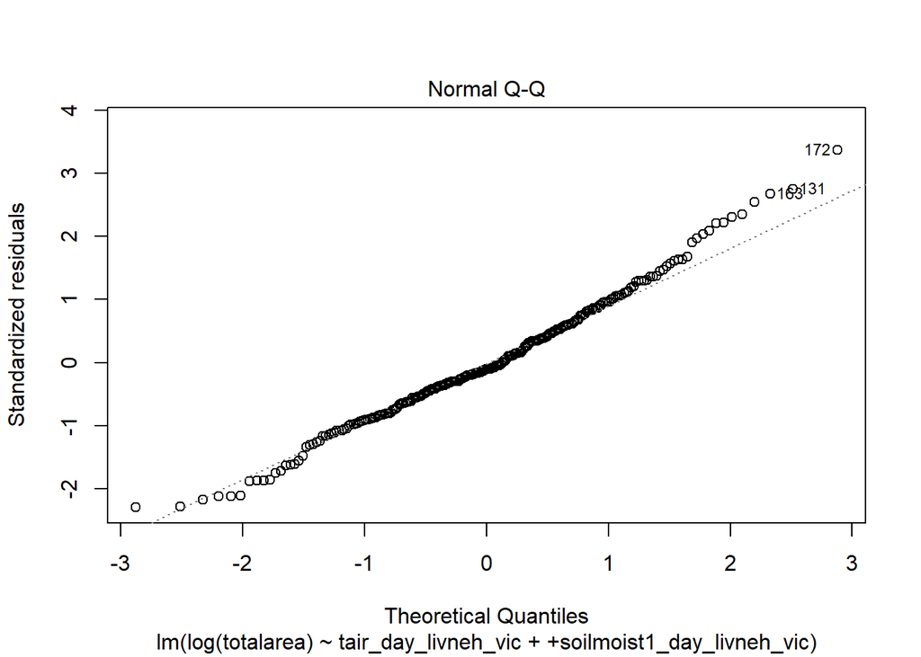

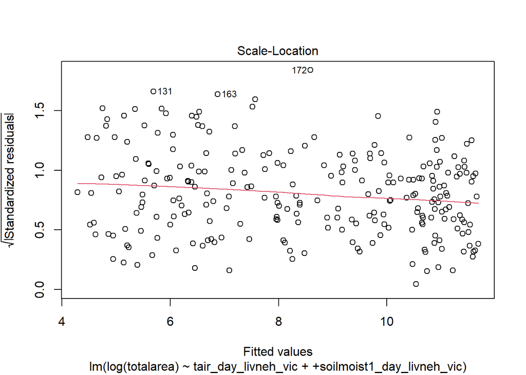

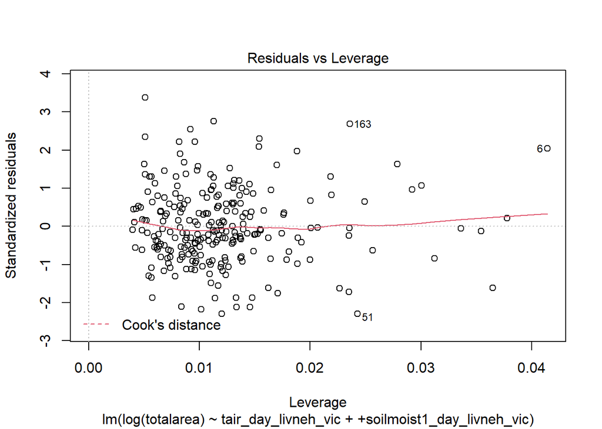

```
##       tair_day_livneh_vic soilmoist1_day_livneh_vic
##                  3.733188                  3.733188
```

We have the model that r-squared value for model of cases 0.8616 model of average fire size 0.3366 model of average total burned size with 0.7391 By the plot check we found that the model of large fire case does not fit well as the residual is not consistent. And the model of average large fire size result shows lack of some normality from qq-plot.